# Reproducible Research Assignment Week 2

Constantin Hartmann

27 2 2020

1. Code for reading in the dataset and/or processing the data

Having loaded all the packages needed, I use the read.csv-function to read in the data and the ymd-function from the lubridate package to convert the date column into the appropriate date format.

```r
library(lubridate)
library(tidyverse)
library(dplyr)

data <- read.csv("C:\\Users\\USER\\Dropbox\\Statistik\\activity.csv", header = TRUE)
data$date <- ymd(data$date)
```

2. Histogram of the total number of steps taken each day

The distribution of the number of steps per day is as follows:

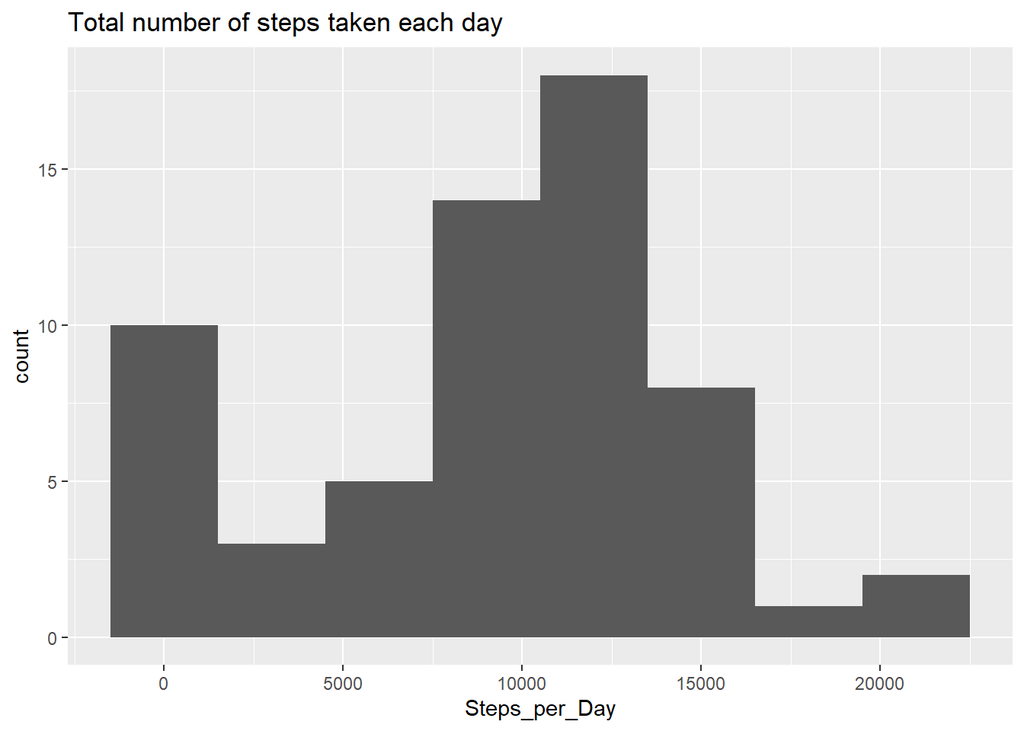

3. Mean and median number of steps taken each day

I used the following code to compute and print the mean and median number of steps taken each day:

```r
steps <- data %>%
        group_by(date) %>%
        mutate(steps_per_day = sum(steps, na.rm = TRUE))

mean(steps$steps_per_day)
median(steps$steps_per_day)
```

[output not shown]

4. Time series plot of the average number of steps taken

I combined geom_line and geom_point plots to build a time series plot of the average number of steps taken:

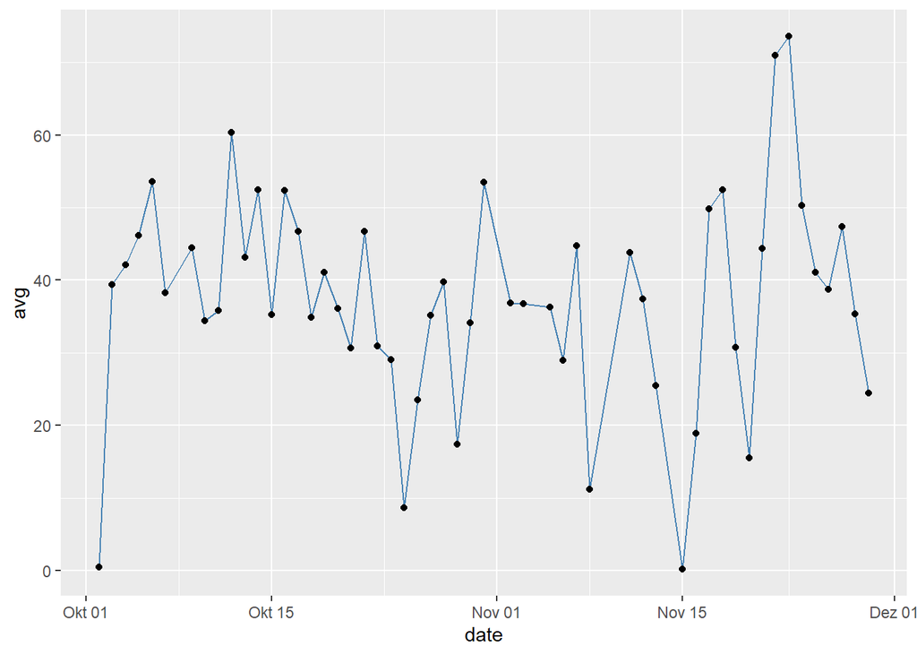

```r
steps_avg <- data %>%
        group_by(date) %>%
        summarize(avg = mean(steps, na.rm = TRUE))
steps_avg
ggplot(na.omit(steps_avg), aes(x = date, y = avg)) +
        geom_line(color = "steelblue") + geom_point()
```

5. The 5-minute interval that, on average, contains the maximum number of steps

I wrote the following code to compute and print out the interval that, on average, contains the maximum number of steps. The respective interval is printed below:

```r
interval_max <- data %>%
        group_by(interval) %>%
        summarize("Interval_Steps_Avg" := mean(steps, na.rm = TRUE)) %>%
        filter(Interval_Steps_Avg == max(Interval_Steps_Avg))

interval_max
```

| interval | Interval_Steps_Avg |
| --- | --- |
| 835 | 206.1698 |

```r
interval_max <- data %>%
        group_by(interval) %>%
        summarize("Interval_Steps_Avg" := mean(steps, na.rm = TRUE)) %>%
        filter(Interval_Steps_Avg == max(Interval_Steps_Avg))
```

```r
steps_avg <- data %>%
        group_by(date) %>%
        summarize("Steps_per_Day" := sum(steps, na.rum = TRUE))
```

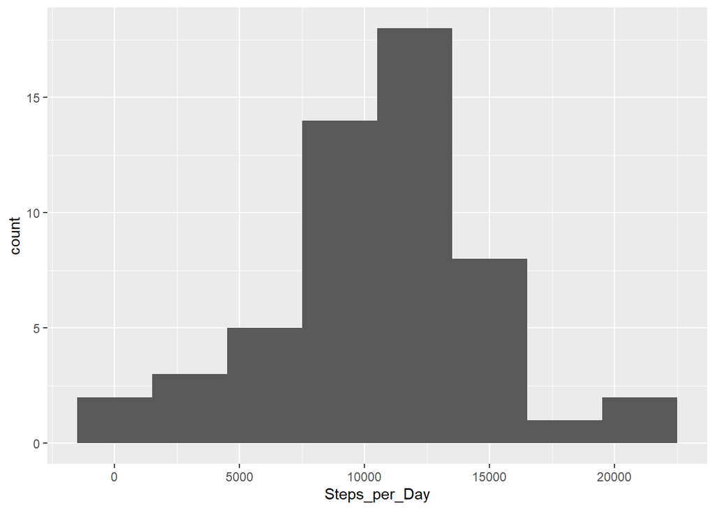

8. Panel plot comparing the average number of steps taken per 5-minute interval across weekdays and weekends

```r
z <- data %>%
        mutate(weekday = weekdays(date)) %>%
        mutate(daytype = case_when((weekday == "Samstag" | weekday == "Sonntag") ~ "Weekend",
                (weekday == "Montag" | weekday == "Dienstag" | weekday == "Mittwoch" | weekday == "Donnerstag" | weekday ==                  "Freitag") ~ "Workingday"))

t <- z %>%
        group_by(interval, daytype) %>%
        #group_by(interval) %>%
        mutate("mean_steps" = mean(steps, na.rm=TRUE))

z$daytype <- as.factor(z$daytype)
```

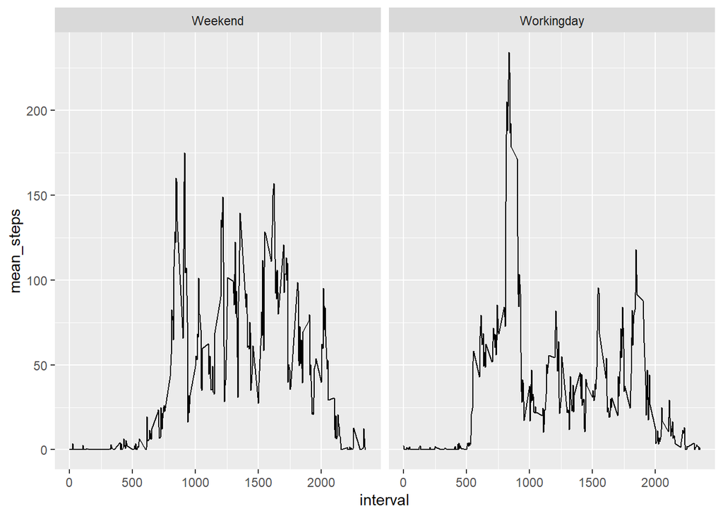

9. All the R code needed to reproduce the results (numbers, plots, etc.) in the report

Finally, the complet R code I wrote:

```r
library(lubridate)
library(tidyverse)
library(dplyr)

data <- read.csv("C:\\Users\\USER\\Dropbox\\Statistik\\activity.csv", header = TRUE)
data$date <- ymd(data$date)

steps_per_day <- data %>%
        group_by(date) %>%
        summarize("Steps_per_Day" := sum(steps, na.rm = TRUE))
ggplot(steps_per_day, aes(x = Steps_per_Day)) + geom_histogram(binwidth = 3000) + ggtitle("Total number of steps taken each day")

steps <- data %>%
        group_by(date) %>%
        mutate(steps_per_day = sum(steps, na.rm = TRUE))

mean(steps$steps_per_day)
median(steps$steps_per_day)

steps_avg <- data %>%
        group_by(date) %>%
        summarize(avg = mean(steps, na.rm = TRUE))
steps_avg
ggplot(na.omit(steps_avg), aes(x = date, y = avg)) +
        geom_line(color = "steelblue") + geom_point()

interval_max <- data %>%
        group_by(interval) %>%
        summarize("Interval_Steps_Avg" := mean(steps, na.rm = TRUE)) %>%
        filter(Interval_Steps_Avg == max(Interval_Steps_Avg))

interval_max

interval_max <- data %>%
        group_by(interval) %>%
        summarize("Interval_Steps_Avg" := mean(steps, na.rm = TRUE)) %>%
        filter(Interval_Steps_Avg == max(Interval_Steps_Avg))

steps_avg <- data %>%
        group_by(date) %>%
        summarize("Steps_per_Day" := sum(steps, na.rum = TRUE))

ggplot(steps_avg, aes(x=Steps_per_Day)) + geom_histogram(binwidth = 3000)

z <- data %>%
        mutate(weekday = weekdays(date)) %>%
        mutate(daytype = case_when((weekday == "Samstag" | weekday == "Sonntag") ~ "Weekend",
                (weekday == "Montag" | weekday == "Dienstag" | weekday == "Mittwoch" | weekday == "Donnerstag" | weekday ==                  "Freitag") ~ "Workingday"))

t <- z %>%
        group_by(interval, daytype) %>%
        #group_by(interval) %>%
        mutate("mean_steps" = mean(steps, na.rm=TRUE))

z$daytype <- as.factor(z$daytype)

ggplot(t, aes(x=interval, y=mean_steps)) + geom_line() + facet_wrap( ~ daytype)
```